# assignment from week01

Darach Miller

2016-02-02

This assignment covers reading in csv data, calculating summary statistics, writing a function and using it, and plotting distributions.

The assignment is the parts that are bolded in red. Other text is context and suggestions. Submit all code and plots as a typeset .html file, typeset from a .Rmd file using `render()` from the `rmarkdown` package.

`birthdata.csv` is a file of 50,000 randomly selected births in the US in 2013 and includes the year, the month and weekday as numeric codes, and the birth weight in grams.

# 1 Reading in the datar

**Read the `birthdata.csv` file into R**. Use read.csv(), setting the file argument equal to the filename in quotes. Note that you must store this object by assigning it with the assignment operator (`<-`) to a variable. Pick a descriptive but easy to type name ( “There are only two hard problems in Computer Science: cache invalidation and naming things.” Phil Karlton ).

To make sure this worked, **use a function we learned about last week to see what kind of variable this new variable is**. Should be a data.frame first - if you did it right.

**Print only the head of the object using `head()`**. This is a handy function to check that reading went okay.

# 2 Using and writing functions

Functions are bits of code that do something. The whole idea is that a function is an implementation of some code, wrapped up all nicely so that the user of the code doesn’t have to think too much about how the function works internally, but rather just provides an argument and the function responds. Like for `sum()`, you provide an arugment of a vector, and it responds with the sum. Simple.  
You put arguments to the function inside the parentheses, so something like `functionNamedFred( c("a","vector","of","values") )`. This would run the `functionNamedFred` on the supplied vector of values.

**Calculate the `mean()`, the `median()`, the `range()`, and the `sd()` of the birthweights**. First, consider how you access the column of birthweights in a data.frame (`[,]`, `$`, or even `[[]]`). Then put it in a function that does what you want.

Can we build functions? Yes. To do so, we need to implement it like so:

```r
myFunktion <- function(zerp) {
  something <- zerp[1]
  somethingElse <- sum(zerp)/something
  return( somethingElse )
}
myFunktion( c(2,3,4) )
```

```
## [1] 4.5
```

You say `function`, then provide the expected arguments inside the parentheses after function, then you put whatever code you want to run inside the `{}`’s, then you `return` something that you’ve calculated. If you’re confused, try modifications to the above code and see the result. Programming via mutagenesis.

**Write a function that calculates the sample standard error of a vector**. Do this by thinking about the formula that you learned in lecture, trying in at the Console in R, then implementing it by coding some code snippet that will calculate it properly. It’s best to test that it works correctly. **Use it to calculate the standard error of the birthweights**.

# 3 Graphical analysis (plotting things)

Use `hist()` on the vector of birthweights to **plot a histogram of the birthweights**. To make it better represent the distribution, you can adjust the breaks by passing a number in as the `breaks=` argument within the parentheses. It should look something like this:

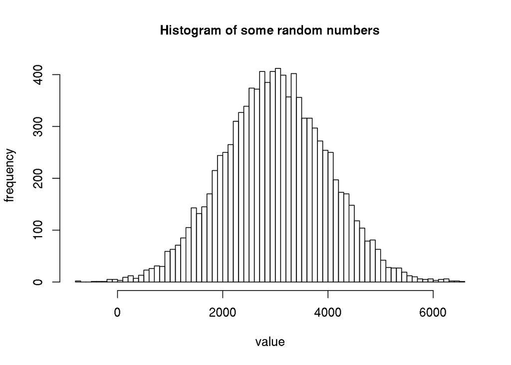

Use the function `abline()` after you’ve plotted a `hist()` to **draw a vertical line at the position of the mean and median of the distribution**. Note that you must open a plot before `abline()` draws on it, similar to how `points()` and `lines()` work. **Give these lines different colors by passing the name of the color to the `col=` argument of `abline()`** (try “red”, “blue”, or “chartreuse4” - check out stat.columbia.edu/~tzheng/files/Rcolor.pdf).

Now, **draw a boxplot using the `boxplot()` function, passing the vector to the `x=` argument**. What are the lines on a boxplot?

Looking back at your histogram and boxplot, tell me **which one you prefer and make two comments on the distributions:** i’m not looking for technical insight, just very surface level obvious stuff here.

# 4 Turn the html file in as your homework